# Review of Surrogate Variable Analysis

Meilei Jiang

## Data variation and heterogeneity

Data variation dues to different kinds of factors:

- modeled factors (primary variables): e.g. class labels
- unmodeled factors : e.g. batch effects: age, sex
- other variation : e.g. white noise, systematic error

In practice, we want to estimate the effects of primary variables as well as discover the unmodeled factors. For instance, we want to training a model by given class labels. However, the effects of primary variables can be blurred by unmodeled factors. Even the data from the same class can have different distributions or a mixture of distribution, which is also called heterogeneity.

The surrogate variable analysis (SVA) builds up a linear model for data variation and tries to construct surrogate variables to represent the batch effects.

### Models for data variation

The $p \times n$ random data matrix $X =(x_1, \dots, x_p)'$ contains $p$ features and each feature $x_i$ = $(x_{i1}, \dots, x_{in})'$ has the expression from $n$ samples. The primary variables are $Y = (y_1, \dots, y_n)'$.

Assume that $\mathbb{E}[x_i|Y] = b_i S(Y) = b_i S$, where $S$ is a matrix of basis function of primary variables with dimension $d \times n$. Also, assume that the marginal model for each $e_i = x_i - b_i S$ is known or approximated sufficiently. In the matrix form, the model can be written as: $X = B S + E$ Moreover, we assume the following decomposition: $X = B S + \Gamma G + U$ Leek and Storey (2008) showed this decomposition exist in the following sense. Suppose that for each $e_i$, there is no Borel measurable function g such that $e_i = g(e_1, \dots, e_{i - 1}, e_{i + 1}, \dots, e_m)$ almost surely. Then there exist matries $\Gamma_{p \times m } G_{r \times n} (r <= n)$ and $U_{p \times n}$ such that: $X = B S + \Gamma G + U$ where the rows of $U$ are jointly independent random vectors so that $\mathbb{P}(u_1, u_2, \dots, u_m) = \mathbb{P}(u_1) \times \mathbb{P}(u_2) \times \dots \times \mathbb{P}(u_m)$ Also $\forall i = 1, \dots, m, u_i \neq 0$ and $u_i = h_i(e_i)$ for a non-random Borel measurable function $h_i$.

When the structure of $G$ is unknown, a set of surrogate variables $\hat{G}$ are constructed by SVA algorithm.

### Detect unmodeled factors

If there are no batch effects, i.e.$\Gamma = 0$, the residual matrix $R = X - \hat{B} S$ should not have unusally large variations in some specific directions. To estimate the dimension $r$ of unmodeled factors, the number of unusally large eigenvalues need to be determined.

In the SVA, an permutation test, a non-parametric approach, is proposed on the residual matrix $R$. It compares the proportion of singular values in $R$ to the proportion of singular values in randomized residual matrices, where each row is permuted individually to break down any structure across rows.

### Construct surrogate variables

The sva algorithm does not attempt to estimate the unmodeled factors $G$. In fact, the sva constructs surrogate variables to represent the variation not caused by primary variables.

Say in the previous step, $\hat{K}$ unusally large eigenvalues are identified. For $\lambda_k, k = 1, \cdots, \hat{K}$, take out its corresponding right singular vectors $e_k$. In some sense, $e_k$ can act as surrogate variable $\hat{g}_k$. However, when $\hat{G}$ and $S$ are not orthogonal，$\hat{B}$, the estimation of the effects of $S$, is biased. So are $R$ and $e_k$.

To reduce this bias, next, subset of feasures $X^{(r)}$ which have a strong assosiation with $e_k$ are idtentified. Then refit the model with $X^{r}$ and obtain the residual matrix $R^{r}$. Last, identify the eigenvector $e_{j_k}^{r}$ of $R^{r}$ which has the largest correlation coefficient with $e_k$.

We can choose $e_{j_k}^{r}$ as $\hat{g}_k$ or continue this iteration. This approach can up-weight the features that show strong assotiation with $G$ and down-weight feasures that show strong association with $S$.

### Simulation study

The current sva algorithm requires that the data has at least 3 feasures. We consider a 2-class toy example and sample in each class has a Gaussian Mixture distribution.

#### 3 feasures data set

Training data are divided into two class:

- Class A: $Y1 \sim (1 - \pi_1) \mathrm{N}\Big( (4, -4, 0)', I_3 \Big) + \pi_1 \mathrm{N}\Big( (4, 4, 0)', I_3 \Big)$, where $\pi_1 \sim \text{Binom}(0.5)$;
- Class B: $Y2 \sim (1 - \pi_2) \mathrm{N}\Big( (-4, -4, 0)', I_3 \Big) + \pi_2 \mathrm{N}\Big( (-4, 4, 0)', I_3 \Big)$, where $\pi_2 \sim \text{Binom}(0.5)$.

The plots of data are as following:

- $X_1$ is the primary variables
- $X_2$ is the batch effects
- $X_3$ is the random noise

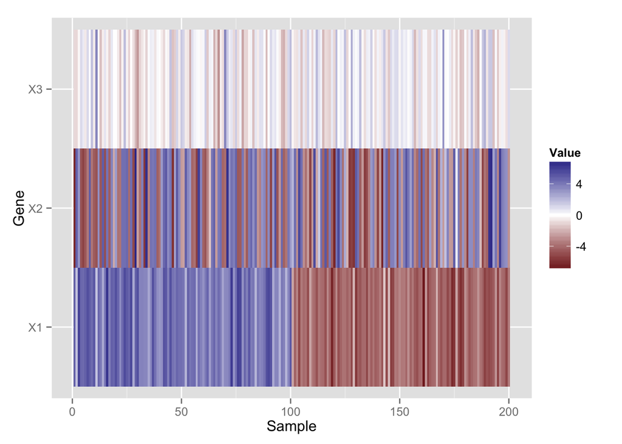

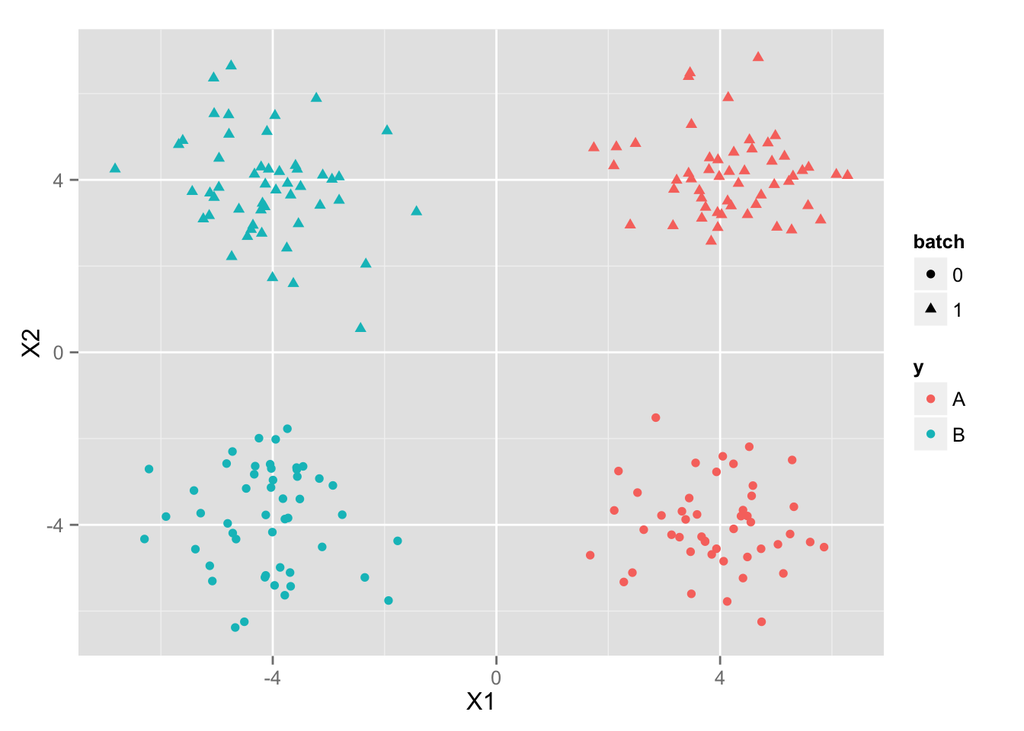

Then, we apply sva algorithm to detect the number of surrogate variables.

```
## [1] 0
```

The algorithm fails to detect the number of SV.

#### 10 feasures data set

Training data are divided into two class:

- Class A: $Y1 \sim (1 - \pi_1) \mathrm{N}\Big( (2, -2, 0, \dots, 0)', I_{10} \Big) + \pi_1 \mathrm{N}\Big( (2, 2, 0, \dots, 0)', I_{10} \Big)$, where $\pi_1 \sim \text{Binom}(0.5)$;
- Class B: $Y2 \sim (1 - \pi_2) \mathrm{N}\Big( (-2, -2, 0, \dots, 0)', I_{10} \Big) + \pi_2 \mathrm{N}\Big( (-2, 2, 0, \dots, 0)', I_{10} \Big)$, where $\pi_2 \sim \text{Binom}(0.5)$.

The plots of data are as following:

- $X_1$ is the primary variables
- $X_2$ is the batch effects
- $X_3, \dots, X_10$ is the random noise

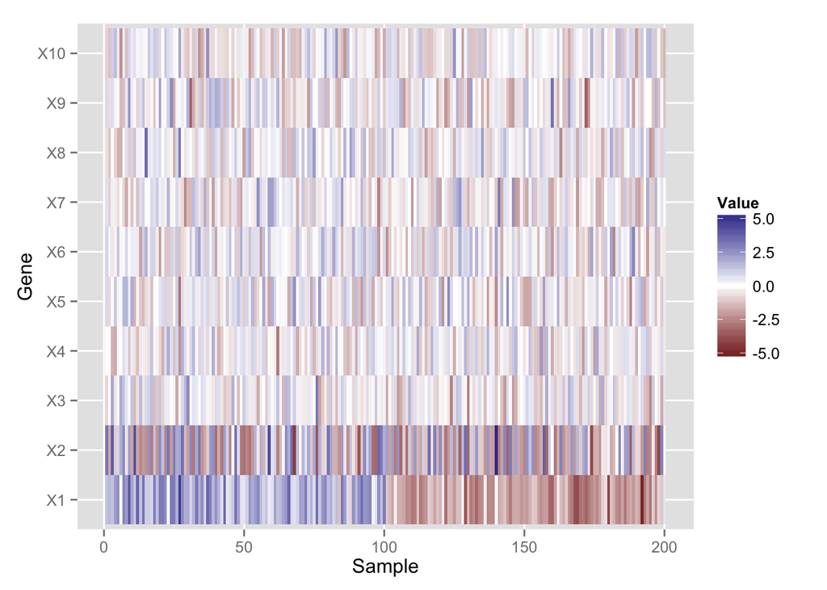

Then, we apply sva algorithm to detect the number of surrogate variables.

```
## [1] 0
```

The algorithm fails to detect the heterogeneity.

#### 100 feasures data set

Training data are divided into two class:

- Class A: $Y1 \sim (1 - \pi_1) \mathrm{N}\Big( (2, -2, 0, \dots, 0)', I_{100} \Big) + \pi_1 \mathrm{N}\Big( (2, 2, 0, \dots, 0)', I_{100} \Big)$, where $\pi_1 \sim \text{Binom}(0.5)$;
- Class B: $Y2 \sim (1 - \pi_2) \mathrm{N}\Big( (-2, -2, 0, \dots, 0)', I_{100} \Big) + \pi_2 \mathrm{N}\Big( (-2, 2, 0, \dots, 0)', I_{100} \Big)$, where $\pi_2 \sim \text{Binom}(0.5)$.

The plots of data are as following:

- $X_1$ is the primary variables
- $X_2$ is the batch effects
- $X_3, \dots, X_100$ is the random noise

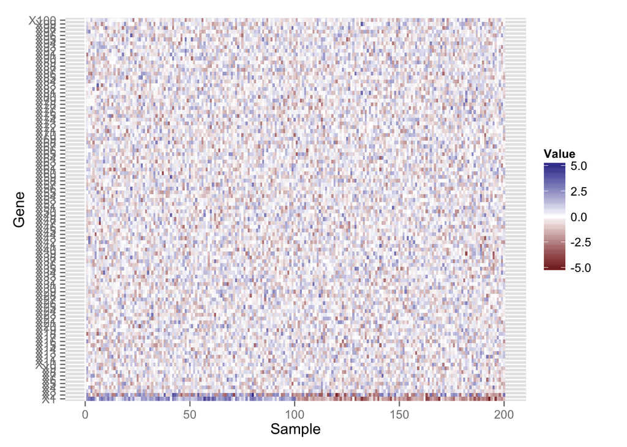

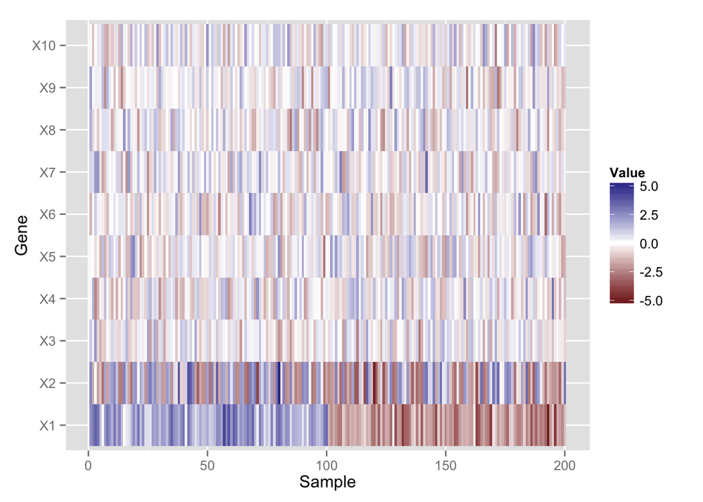

Then, we apply sva algorithm to detect the number of surrogate variables.

```
## [1] 1
```

Then we want to see the details of detecting the surrogate variables. Especially, we want to understand the scree plot in each permuation residual matrix.

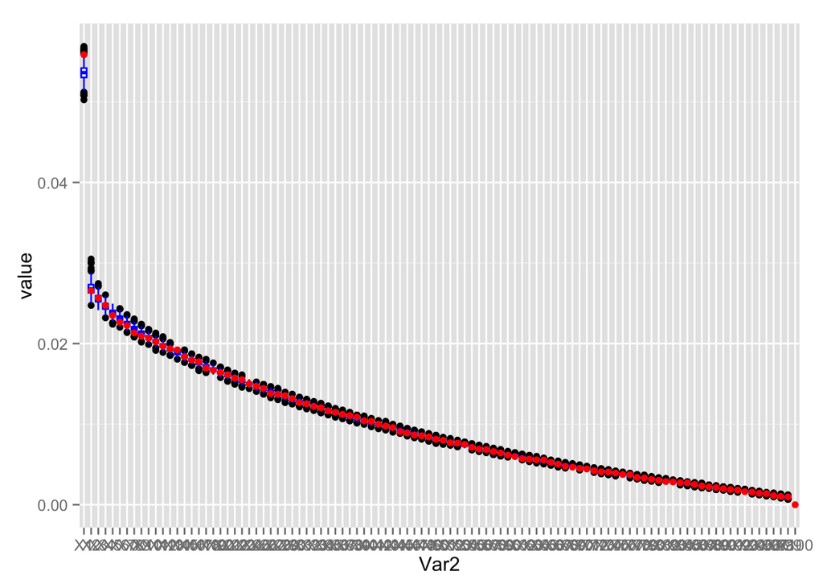

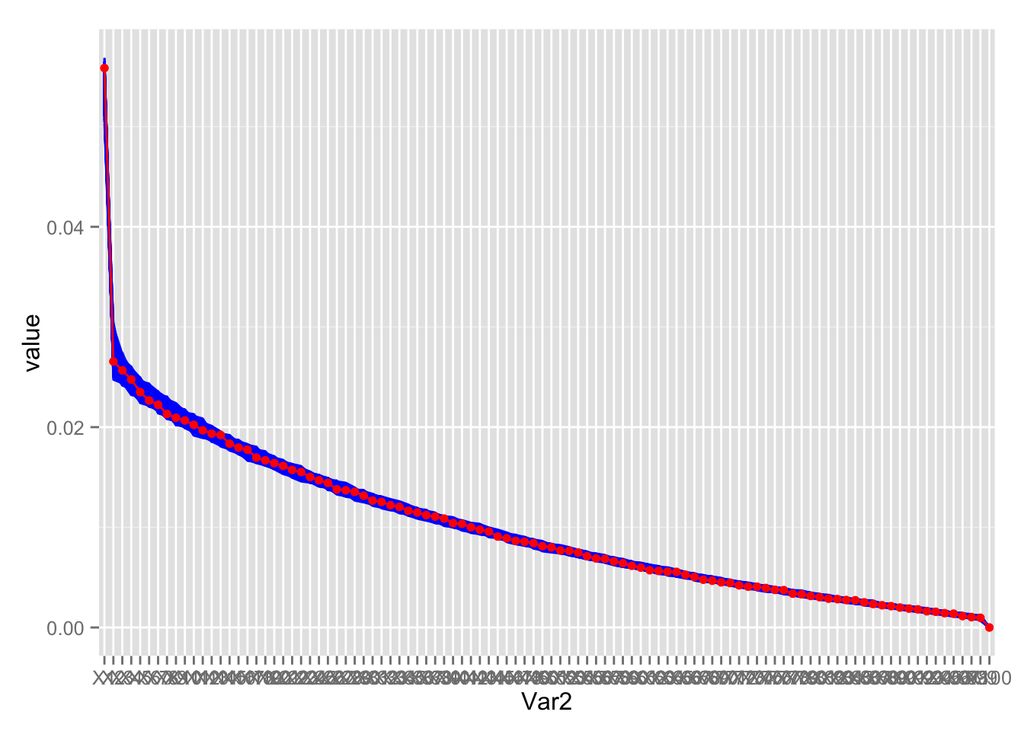

Next we construct SV.

```
## Number of significant surrogate variables is:  1
## Iteration (out of 5 ):1  2  3  4  5
```

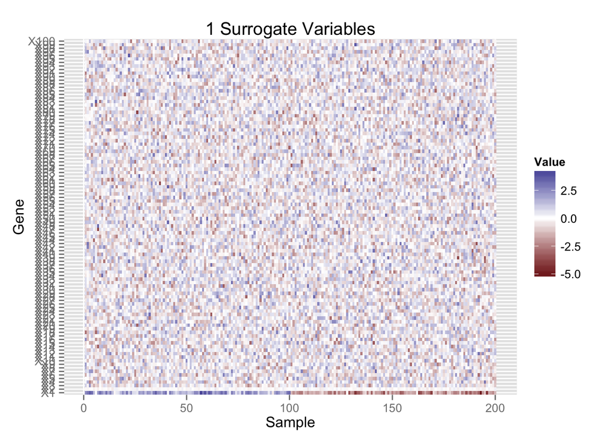

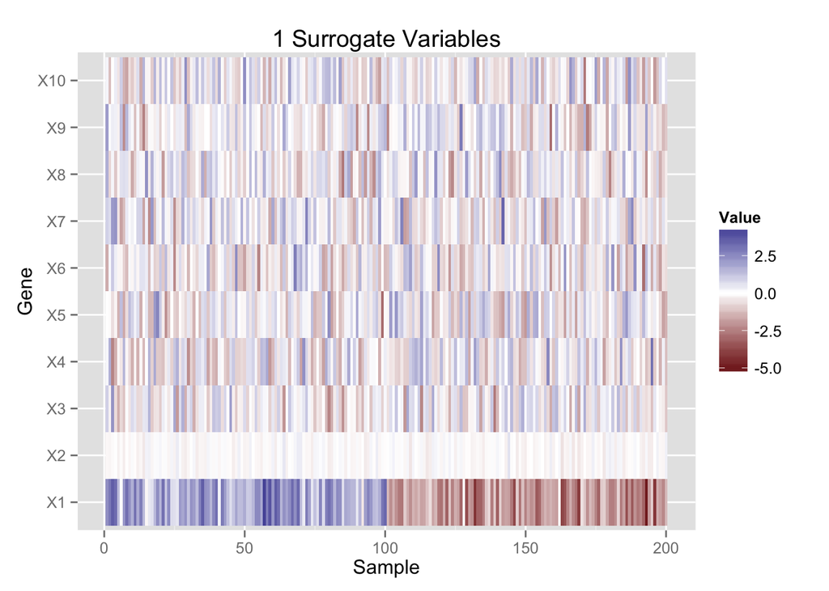

##### Scale different mixture batch effects

There are 80 samples. The samples belong to two classes. First 40 samples belong to Class 1 and others belong to Class 2. The samples are collected from two Batches. Batch 1 contains Sample 1 to Sample 20 and Sample 41 to Sample 60. Other samples come from Batch 2.

Each sample has 100 features. - $X_1$ is the primary variables. For Class 1, $X_1 = 2$; for Class 2, $X_1 = -2$. - $X_2$ is the batch effects. For Batch 1, $X_2 \sim \mathrm{N}(0, 0.1)$; for Batch 2, $X_2 \sim \mathrm{N}(0, 2)$. - $X_3, \dots, X_100$ is the random noise.

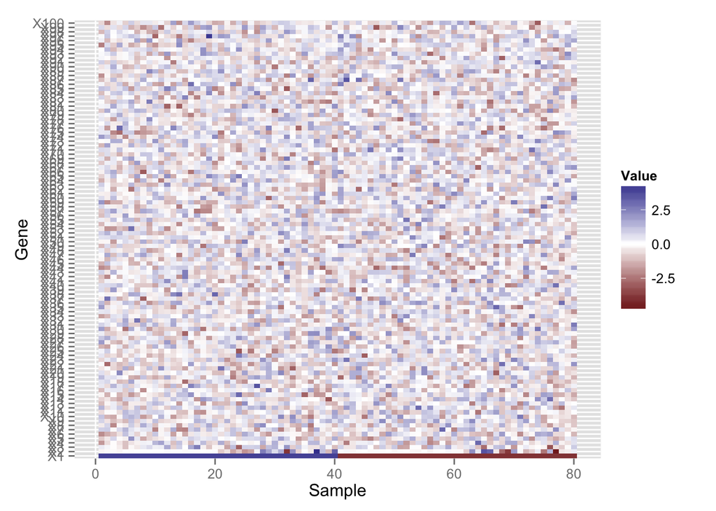

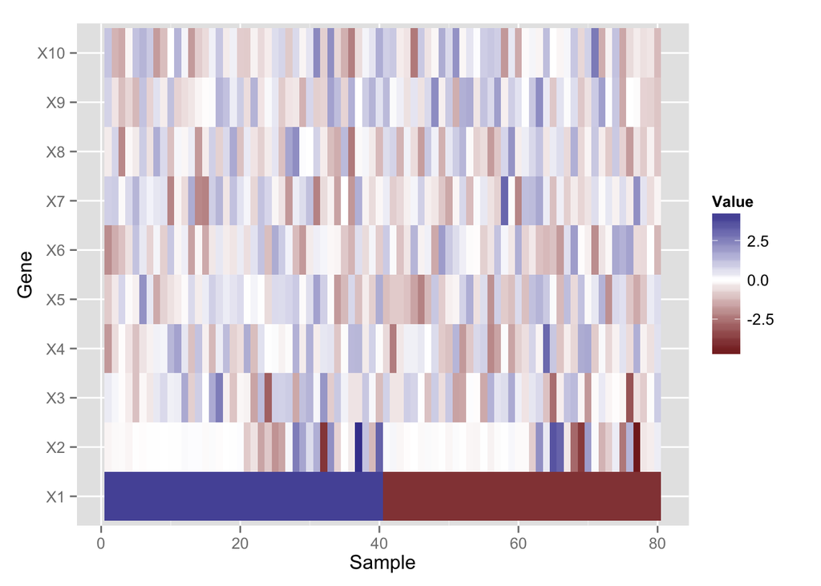

Then, we apply sva algorithm to detect the number of surrogate variables.

```
## [1] 0
```

```
## [1] 0
```

The SVA fails to detect the unmodeled factor. However, I can still try to construct the SV by setting the number of SV as 1 mannually.

```
## Number of significant surrogate variables is:  1
## Iteration (out of 5 ):1  2  3  4  5
```

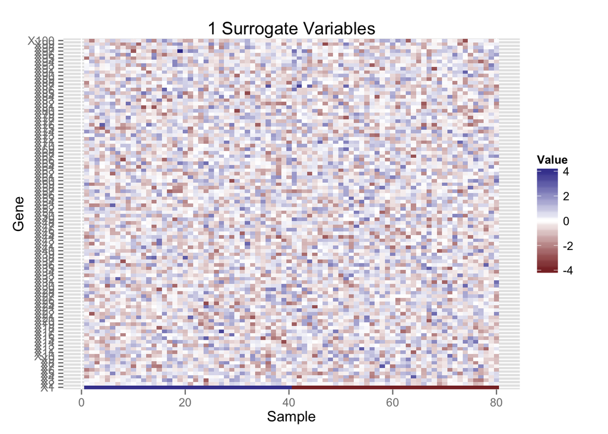

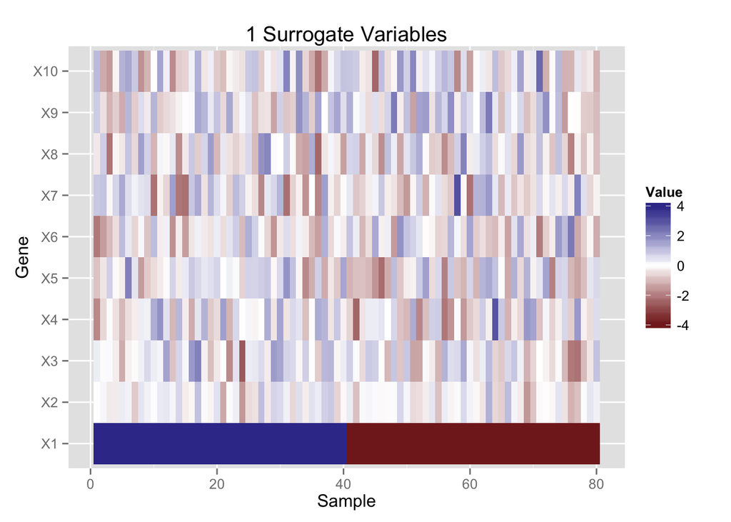

#### Unbalanced Batch Effect

In these simulations, there are 80 samples. The samples belong to two classes. First 40 samples belong to Class 1 and others belong to Class 2. The samples are collected from two batches. But the propotion of samples in Class 1 from Batch 1 is different with the propotionof samples in Class 2 from Batch 1.

##### Mean Heterogeneity Batch Effect

Each sample has 100 features:

- $X_1$ is the primary variables. For Class 1, $X_1 = 2$; for Class 2, $X_1 = -2$.
- $X_2$ is the batch effects. For Batch 1, $X_2 \sim \mathrm{N}(2, 1)$; for Batch 2, $X_2 \sim \mathrm{N}(-2, 1)$. $\pi_1$ of Class 1 from Batch 1 and $\pi_2$ of Class 2 from Batch 1. The others from Batch 2.
- $X_3, \dots, X_100$ is the random noise.

We do simulation for three sets of $\pi_1$ and $\pi_2$:

```
## [1] "n.sv1 = 0. Fail to find out the batch effect."
```

```
## [1] "n.sv2 = 0. Fail to Find out the batch effect."
```

```
## [1] "n.sv3 = 0. Fail to find out the batch effect."
```

```
## [1] "Manually set the number of surrogate variable as 1 and apply sva to remove the effects of surrogate variable."
```

```
## Number of significant surrogate variables is:  1
## Iteration (out of 5 ):1  2  3  4  5
```

```
## Number of significant surrogate variables is:  1
## Iteration (out of 5 ):1  2  3  4  5
```

```
## Number of significant surrogate variables is:  1
## Iteration (out of 5 ):1  2  3  4  5
```

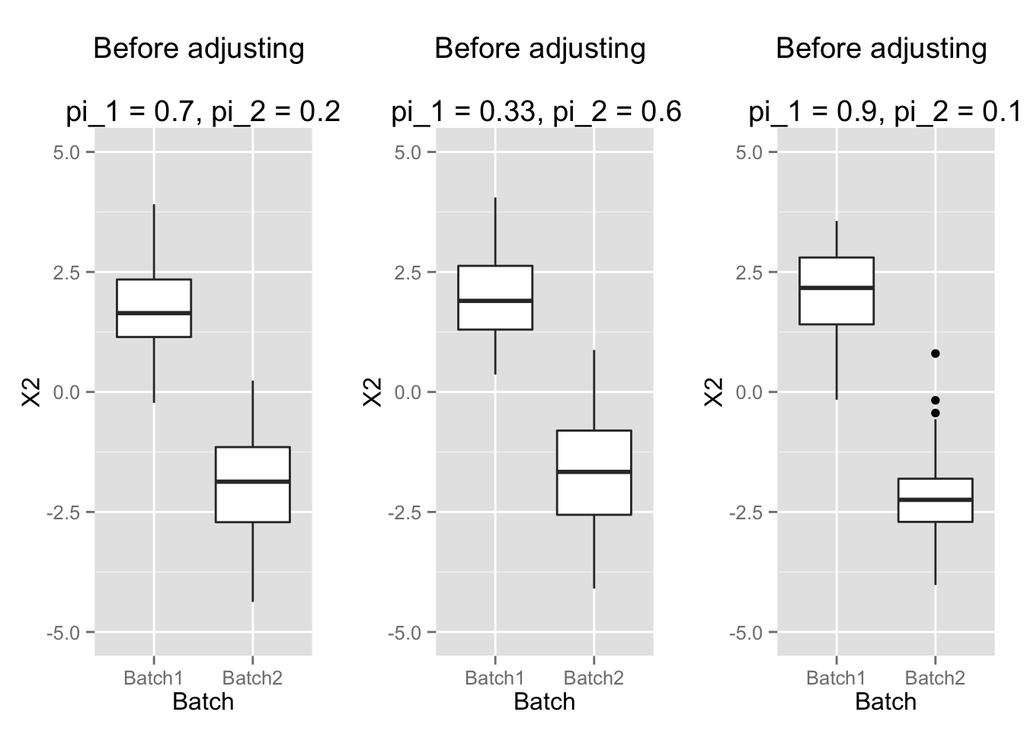

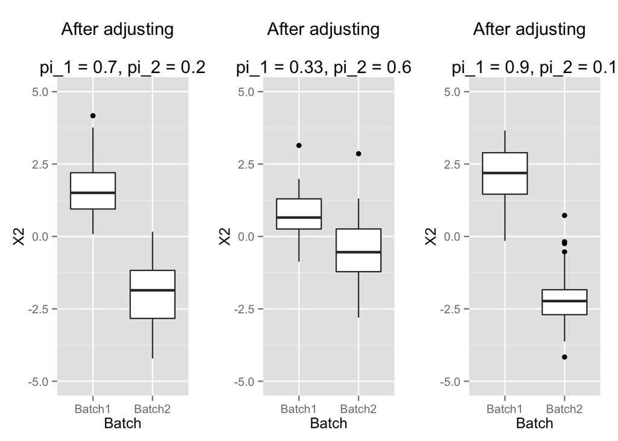

```
## [1] "Analysis of detecting the surgoate variables"
```

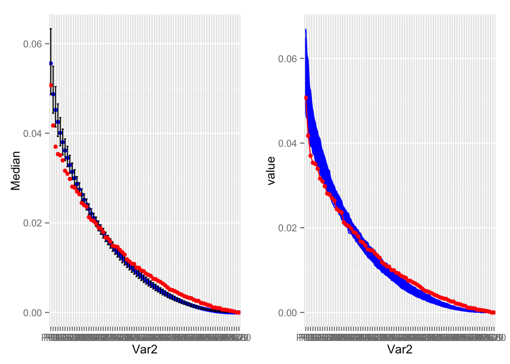

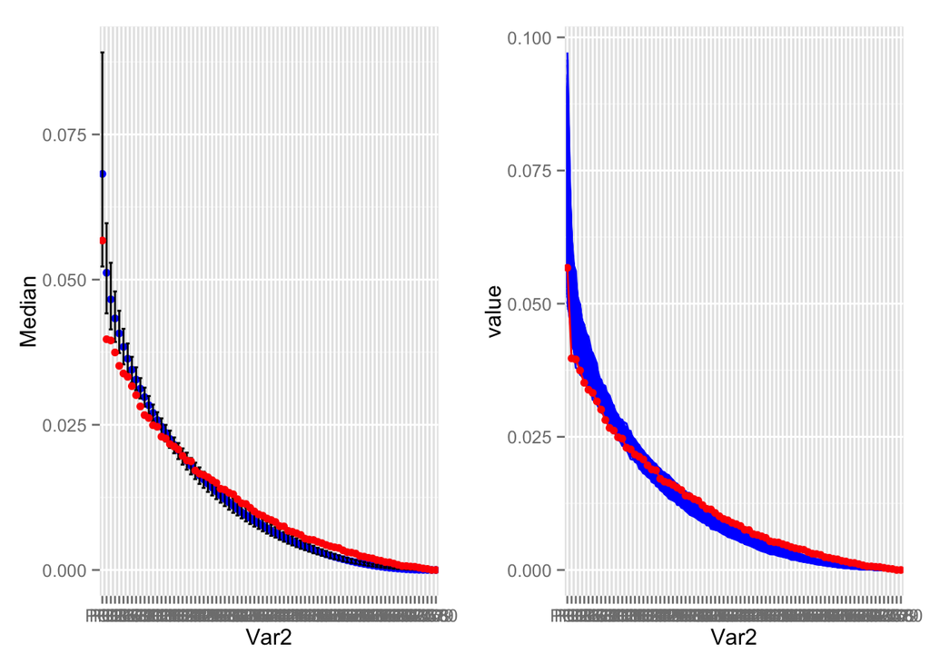

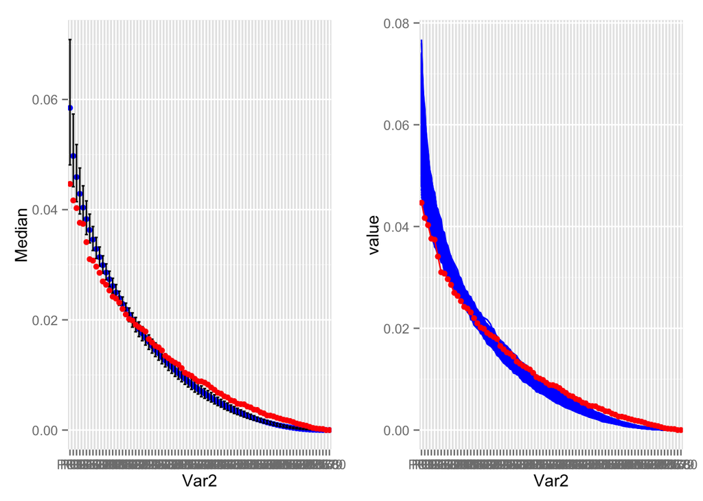